# Statistisk inferensteori Vektorvärda parametrar (H & B, Kapitel 5)

## Likelihoodteori för vektorvärda parametrar

## Scorevektor och informationsmatris

**Definition:** (H & B, definition 5.1, 5.3) Score-vektorn till en differentierbar likelihood-funktion av en vektorvärd parameter \(\theta=(\theta_1,\ldots,\theta_d)\) är log-likeliehoodfunktionens gradient: \[ S(\theta)=\nabla\log L(\theta)=(\frac{d\log L(\theta)}{d\theta_1},\ldots,\frac{d\log L(\theta)}{d\theta_d}). \]

Fishers informationsmatris för en två gånger differentierbar likelihood-funktion av en vektorvärd parameter \(\theta=(\theta_1,\ldots,\theta_d)\) är; \[ I(\theta)=-H\log L(\theta)=-\bigl(\frac{d^2}{d\theta_i\,d\theta_j}\log L(\theta)\bigr). \]

## Förväntad Fisherinformation och egenskaper hos Score

**Definition:** (H & B, kap 5.4) Den förväntade Fisherinformationsmatrisen är \[ J(\theta)=E_\theta(I(\theta)) \]

**Sats:** (H & B, result 5.3) Under regularitetsvillkor är \[ E_\theta(S(\theta))=0 \] och \[ Cov_\theta(S(\theta))=J(\theta). \]

## Multivariata CLT

**Sats:** Om \(X_i\in\mathbf{R}^p\), \(i=1,\ldots,n\) är oberoende likafördelade vektorer med medelvärdesvektor \(\mu\) och kovariansmatris \(\Sigma\) (med ändliga element), då \[ \sqrt{n}(\bar{X}-\mu)\rightarrow Z\sim N(0,\Sigma), \] i fördelning då \(n\rightarrow\infty\).

**Sats:** Om \(X=(X_1,\ldots,X_d) \sim N(\mu, \Sigma)\) så är \[ (X-\mu)\Sigma^{-1/2}\sim N(0, I) \] och \[ (X-\mu)\Sigma^{-1}(X-\mu)^T\sim \chi^2(d). \]

## Multivariata score-statistikan

**Följdsats:** Låt \(S(\theta)\in\mathbf{R}^d\) vara scorefunktionen baserad på oberoende likafördelade variabler \(X_1,\ldots,X_n\sim P_\theta\), då \[ \frac{1}{\sqrt{n}}S(\theta)\rightarrow Z\sim N(0,J_1(\theta)), \] \[ S(\theta)J(\theta)^{-1/2}\rightarrow Z\sim N(0,I), \] och \[ S(\theta)J(\theta)^{-1}S(\theta)^T\rightarrow Z \sim \chi^2(d) \] i fördelning då \(n\rightarrow\infty\).

## Multivariat Taylor

\[ f(x)\approx f(x_0)+\nabla f(x_0)(x-x_0)^T+\frac{1}{2}(x-x_0)Hf(x_0)(x-x_0)^T \] \[ \nabla f(x) \approx \nabla f(x_0) + (x-x_0)Hf(x_0) \]

## Multivariata Wald-statistikan

**Resultat:** Under regularitetsvillkor, om \(\hat{\theta}\in\mathbf{R}^d\) är ML-skattaren baserad på oberoende likafördelade variabler \(X_1,\ldots,X_n\sim P_\theta\), då

\[ \sqrt{n}(\hat{\theta}-\theta)\rightarrow Z \sim N(0, J_1(\theta)^{-1}), \] \[ (\hat{\theta}-\theta)J(\theta)^{1/2}\rightarrow Z \sim N(0, I) \] och \[ (\hat{\theta}-\theta)J(\theta)(\hat{\theta}-\theta)^T\rightarrow Z \sim \chi^2(d) \] i fördelning då \(n\rightarrow\infty\).

## Multivariata likelihood-kvot statistikan

**Resultat:** Under regularitetsvillkor, om \(\hat{\theta}\in\mathbf{R}^d\) är ML-skattaren baserad på oberoende likafördelade variabler \(X_1,\ldots,X_n\sim P_\theta\), då

\[ -2\tilde{l}(\theta)=-2(l(\theta)-l(\hat{\theta}))\rightarrow Z \sim \chi^2(d). \] i fördelning då \(n\rightarrow\infty\).

## Livslängder, Weibullfördelning

Täthetsfunktionen för den aktuella Weibullfördelningen är \[ p(x_i|\alpha,\beta)=\alpha\beta(x_i\beta)^{\alpha-1}\exp(-(x_i\beta)^\alpha) \] med logaritm \[ \log(p(x_i|\alpha,\beta))=\log(\alpha)+\alpha\log(\beta)+(\alpha-1)\log(x_i)-(x_i\beta)^\alpha \] vars gradient är \[ (\frac{1}{\alpha}+\log(x_i\beta)(1-(x_i\beta)^\alpha),\quad\frac{\alpha}{\beta}(1-(x_i\beta)^{\alpha})) \]

## Livslängder, Weibullfördelning

Hessianen blir \[\begin{pmatrix} -\frac{1}{\alpha^2}-\log(x_i\beta)^2(x_i\beta)^{\alpha}& -\frac{(x_i\beta)^{\alpha}+\alpha\log(x_i\beta)(x_i\beta)^{\alpha}-1}{\beta}\\ -\frac{(x_i\beta)^{\alpha}+\alpha\log(x_i\beta)(x_i\beta)^{\alpha}-1}{\beta} & -\frac{\alpha}{\beta^2}((\alpha-1)(x_i\beta)^\alpha+1) \end{pmatrix} \]

## Livslängder, Weibullfördelning

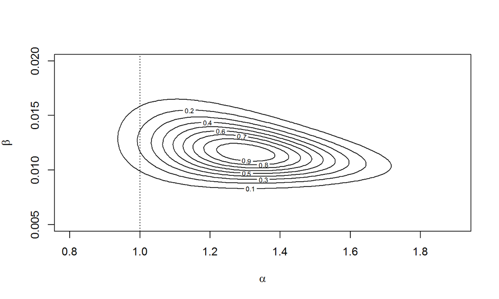

## Livslängder, Weibullfördelning

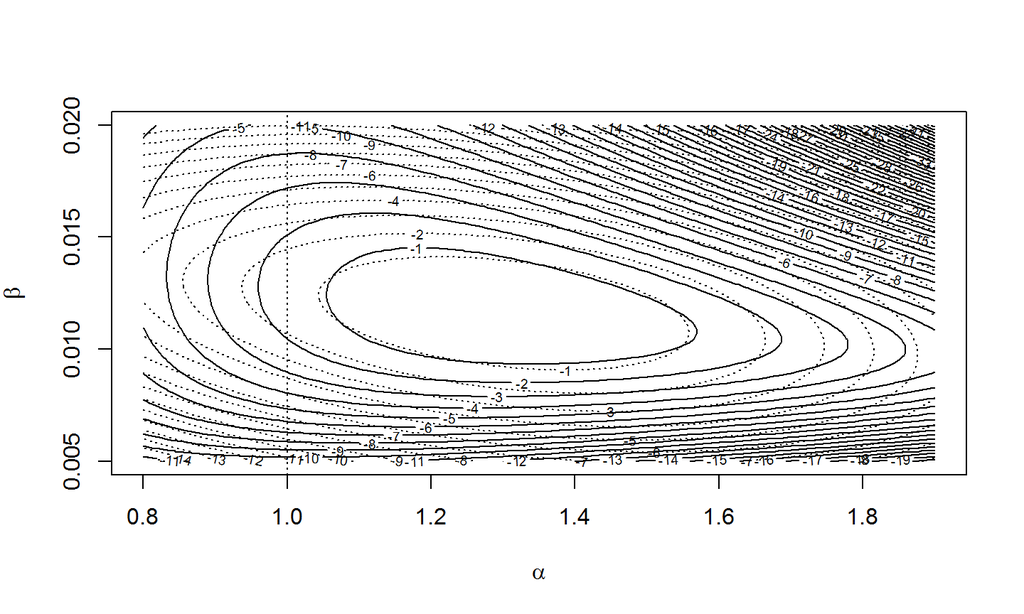

## Konfidensregioner, Wald och likelihood

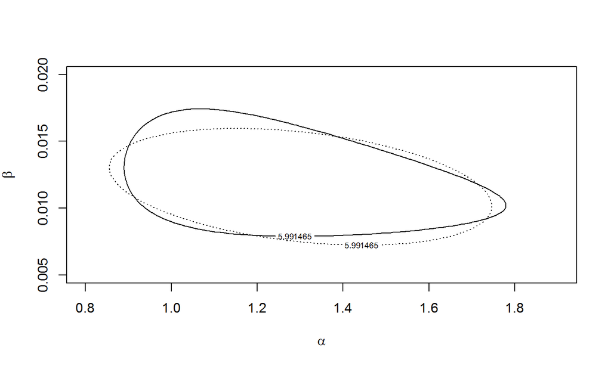

## Tester, \(H_0:(\alpha, \beta)=(1,0.01)\)

```r
a0 <- 1; b0 <- 0.01
S <- S.weib(a0, b0, ac)
I <- I.weib(a0, b0, ac)
TS <- S %*% solve(I) %*% cbind(S)
1 - pchisq(TS, 2)
```

```
##               S
## [1,] 0.08411721
```

```r
d <- (theta.hat - c(a0, b0))
TW <- d %*% I %*% cbind(d)
1 - pchisq(TW, 2)
```

```
##              d
## [1,] 0.1417524
```

## Tester, \(H_0:(\alpha, \beta)=(1,0.01)\)

```r
TL <- -2 * (l.weib(a0, b0, ac) - l.weib(theta.hat[1], theta.hat[2], ac))
1 - pchisq(TL, 2)
```

```
## [1] 0.1061821
```

## Konfidensregioner, Wald och likelihood

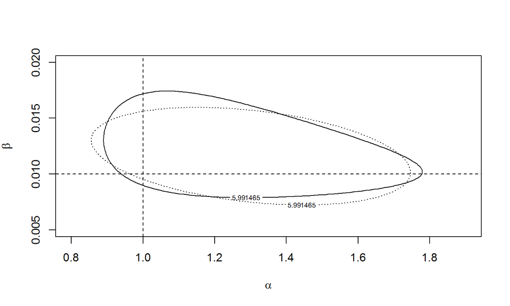

## Marginella metoder

## Marginella Wald-intervall

Om \[ Cov(\hat{\theta}-\theta)\approx J(\theta)^{-1} \] så \[ Var(\hat{\theta}_i-\theta_i)\approx diag(J(\theta)^{-1})_i \] och \[ se(\hat{\theta}_i)=diag(I(\hat{\theta})^{-1})_i. \]

## Marginella Wald-intervall

```r
se <- sqrt(diag(solve(I.weib(alpha.hat, beta.hat, ac))))
se
```

```
## [1] 0.182014959 0.001785406
```

```r
C.alpha <- alpha.hat + se[1] * qnorm(c(0.025, .975))
C.alpha
```

```
## [1] 0.9440732 1.6575588
```

```r
C.beta <- beta.hat + se[2] * qnorm(c(0.025, .975))
C.beta
```

```
## [1] 0.008096586 0.015095247
```

## Profil och skattad likelihood

**Definition:** (H & B, definition 5.4, 5.5)

Antag att parametervektorn kan delas in i en intresse-parameter \(\theta\) och en skräp-parameter \(\eta\), då ges den skattade likelihooden för \(\theta\) av \[ L_e(\theta)=L(\theta, \hat{\eta}), \] där \((\hat{\theta},\hat{\eta})\) är ML-skattningen av hela parametervektorn. Vidare ges profil-likelihooden av \[ L_p(\theta)=\max_{\eta}L(\theta, \eta)=L(\theta, \hat{\eta}(\theta)). \]

## Livslängder, skattad och profil för \(\beta\)

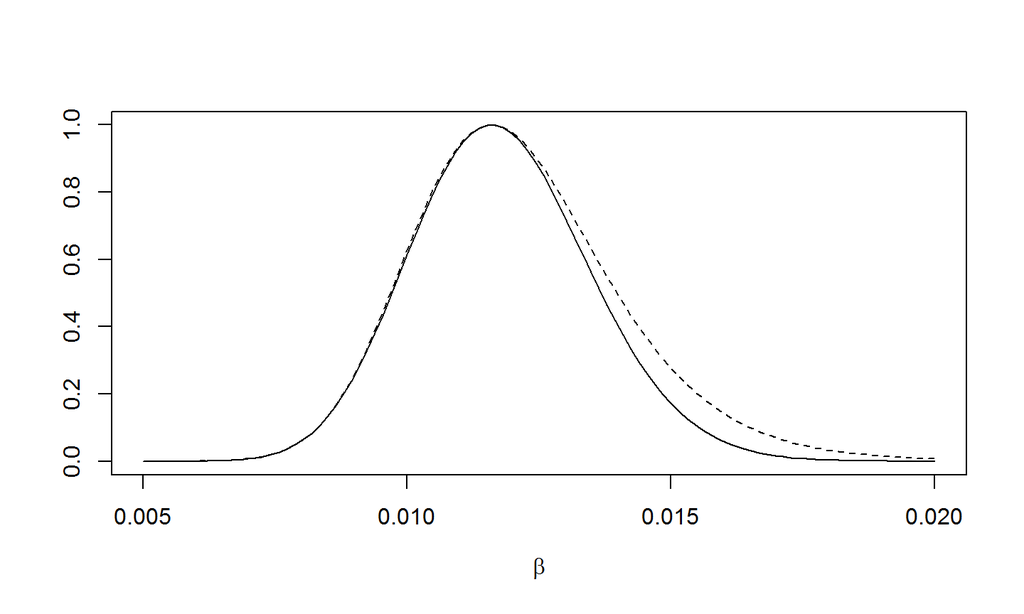

## Livslängder, skattad och profil för \(\beta\)

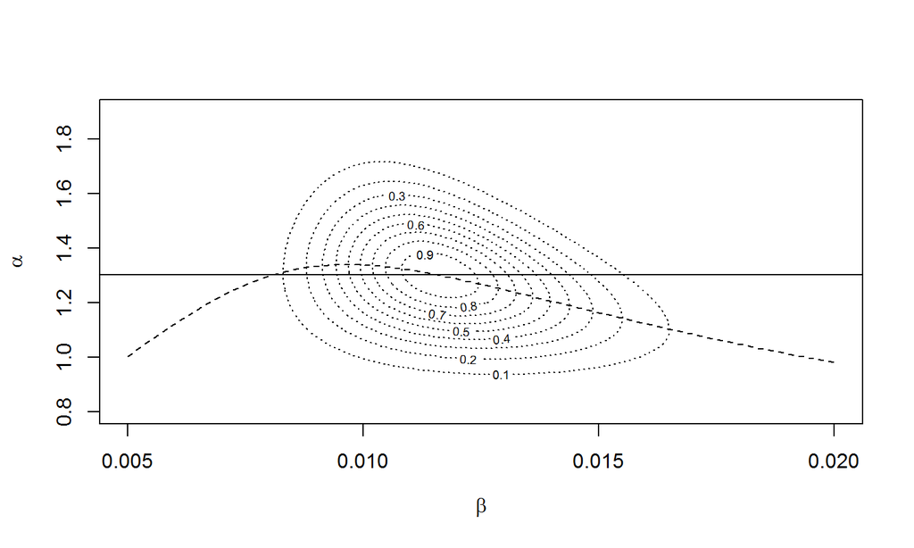

## Profil-loglikelihoodens krökning

**Resultat:** (H & B, Result 5.1) Låt \(L(\theta,\eta)\) ha observerad Fisherinformation \[I(\hat{\theta},\hat{\eta})= \begin{pmatrix} I_{\theta\theta} & I_{\theta\eta}\\ I_{\eta\theta} & I_{\eta\eta} \end{pmatrix} \text{ med invers } I(\hat{\theta},\hat{\eta})^{-1}= \begin{pmatrix} I^{\theta\theta} & I^{\theta\eta}\\ I^{\eta\theta} & I^{\eta\eta} \end{pmatrix} \] då är profil-loglikelihoodens negativa krökning \[ -H l_p(\hat{\theta})=(I^{\theta\theta})^{-1} \] och skattade loglikelihoodens negativa krökning \[ - H l_e(\hat{\theta})=I_{\theta\theta}. \]

## Profil-loglikelihoodens krökning

Ger kvadratiska approximationer \[ -2(l_p(\theta)-l_p(\hat{\theta}))\approx (\hat{\theta}-\theta) (I^{\theta\theta})^{-1} (\hat{\theta}-\theta)^T\sim \chi^2(\dim(\theta)) \] och \[ -2(l_e(\theta)-l_e(\hat{\theta}))\approx (\hat{\theta}-\theta) I_{\theta\theta} (\hat{\theta}-\theta)^T \sim ??. \]